# ME314 Homework 3

## Problem 5 (10pts)

Simulate the double-pendulum system in Problem 4 with initial condition $\theta_1=\theta_2=-\frac{\pi}{2}, \dot{\theta}_1=\dot{\theta}_2=0$ for $t\in[0,10]$ and $dt=0.01$. Numerically evaluate the Hamiltonian of this system from the simulated trajectory, and plot it.

> *Hint 1: The Hamiltonian can be numerically evaluated as a function of $\theta_1, \theta_2, \dot{\theta}_1, \dot{\theta}_2$, which means for each time step in the simulated trajectory, you can compute the Hamiltonian for this time step, and store it in a list or array for plotting later. This doesn't need to be done during the numerical simulation, after you have the simulated the trajectory you can access each time step within another loop.*

**Turn in: Include the code used to numerically evaluate and plot the Hamiltonian, as well as the code output, which should be the plot of Hamiltonian. Make sure you label the plot with axis labels, legend and a title.**

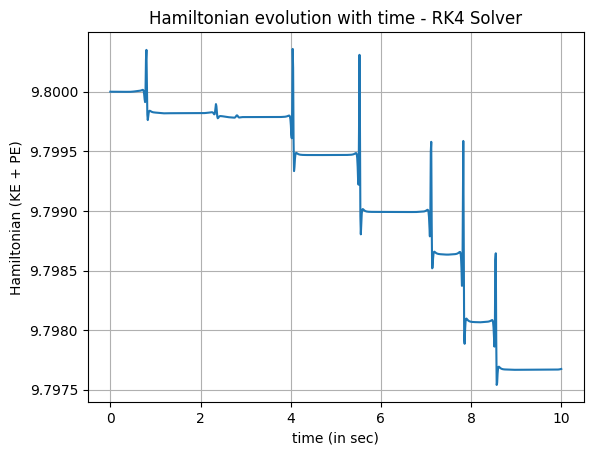

```python
# Dynamics of the system
def double_pendulum(x):
  """
  System dynamics function (extended)

  Parameters
  ============
  x_dot: NumPy array
      s = [th1, th1_dot, th2, th2_ddot] is the extended system
      state vector

  Return
  ============
  x_ddot: NumPy array
      time derivative of input state vector,
      x_ddot = [th1_dot, th1_ddot, th2_dot, th2_ddot]
  """

  th1_k, th1_dot_k, th2_k, th2_dot_k = x


  th1_ddot_k = th1_ddot(th1_k, th1_dot_k, th2_k, th2_dot_k)
  th2_ddot_k = th2_ddot(th1_k, th1_dot_k, th2_k, th2_dot_k)

  return np.array([th1_dot_k, th1_ddot_k, th2_dot_k, th2_ddot_k])

def compute_hamiltonian_traj(x_traj):
  """
  System dynamics function (extended)

  Parameters
  ============
  x_dot: NumPy array
    s = [th1, th1_dot, th2, th2_ddot] is the extended system
    state vector

  Return
  ============
  x_ddot: NumPy array
    time derivative of input state vector,
    x_ddot = [th1_dot, th1_ddot, th2_dot, th2_ddot]
  """

  hamiltonian_traj = []
  for col in range(x_traj.shape[1]):
    th1_k, th1_dot_k, th2_k, th2_dot_k = x_traj[:, col]
    # print(x_traj[:, col])
    h_k = lambdified_hamiltonian(th1_k, th1_dot_k, th2_k, th2_dot_k)
    hamiltonian_traj.append(h_k)

  return np.array(hamiltonian_traj)

# State vector is of the form (th1, th1_dot, th2, th2_ddot)
# Define the initial state
x0 = np.array([-np.pi/2, 0, -np.pi/2, 0])

# Simulation parameters
t0 = 0
tf = 10
dt = 0.01
N = int((tf - t0)/dt)
tvec = np.linspace(t0, tf, N)

# print(double_pendulum(x0))
x_traj_rk4 = simulate(double_pendulum, x0, [t0, tf], dt, integrate)
# print(x_traj.shape)
hamiltonian_traj_rk4 = compute_hamiltonian_traj(x_traj_rk4)

# Set title and labels
plt.title(r"Hamiltonian evolution with time - RK4 Solver")
plt.xlabel("time (in sec)")
plt.ylabel("Hamiltonian (KE + PE)")
plt.grid(True)
plt.plot(tvec, hamiltonian_traj_rk4)
```

## Problem 6 (15pts)

In the previously provided code for simulation, the numerical integration is a forth-order Runge–Kutta integration. Now, write down your own numerical integration function using Euler's method, and use your numerical integration function to simulate the same double-pendulum system with same parameters and initial condition in Problem 4. Compute and plot the Hamiltonian from the simulated trajectory, what's the difference between two plots?

> *Hint 1: You will need to implement a new ${\tt integrate()}$ function. This function takes in three inputs: a function $f(x)$ representing the dynamics of the system state $x$ (you can consider it as $\dot{x}=f(x)$), current state $x$ (for example $x(t)$ if $t$ is the current time step), and integration step length $dt$. This function should output $x(t+dt)$, for which the analytical solution is $x(t+dt) = x(t) + \int_t^{t+dt} f(x(\tau)) d\tau$. Thus, you need to think about how to numerically evaluate this integration using Euler's method.*

> *Hint 2: The implemented function should have the same input-output structure as the previous one.*

> *Hint 3: After you implement the new integration function, you can use the same helper function ${\tt simulate()}$ for simulation. You just need to input replace the integration function name as the new one (for example, your new function can be named as ${\tt euler\_integrate()}$). Please carefully read the comments in the ${\tt simulate()}$ function. Below is the template/example of how to implement the new integration function and use it for simulation.*

**Turn in: Include you numerical integration function (you only need to include the code for your new integration function), and the resulting plot of Hamiltonian. Make sure you label the plot appropriately with axis labels, legend and a title.**

```python
##########################################################################
# Below is an example of how to implement a new integration
# function and use it for simulation

##########################################################################
# This is the same "simulate()" function we provided
# in previous homework.
def simulate(f, x0, tspan, dt, integrate):
    """
    This function takes in an initial condition x0, a timestep dt,
    a time span tspan consisting of a list [min_time, max_time],
    as well as a dynamical system f(x) that outputs a vector of the
    same dimension as x0. It outputs a full trajectory simulated
    over the time span of dimensions (xvec_size, time_vec_size).

    Parameters
    ============
    f: Python function
        derivate of the system at a given step x(t),
        it can considered as \dot{x}(t) = func(x(t))
    x0: NumPy array
        initial conditions
    tspan: Python list
        tspan = [min_time, max_time], it defines the start and end
        time of simulation
    dt:
        time step for numerical integration
    integrate: Python function
        numerical integration method used in this simulation

    Return
    ============
    x_traj:
        simulated trajectory of x(t) from t=0 to tf
    """
    N = int((max(tspan)-min(tspan))/dt)
    x = np.copy(x0)
    tvec = np.linspace(min(tspan),max(tspan),N)
    xtraj = np.zeros((len(x0),N))
    for i in range(N):
        xtraj[:,i]=integrate(f,x,dt)
        x = np.copy(xtraj[:,i])
    return xtraj

##########################################################################
# This is the same "integrate()" function we provided in previous homework.
def integrate(f, xt, dt):
    """
    This function takes in an initial condition x(t) and a timestep dt,
    as well as a dynamical system f(x) that outputs a vector of the
    same dimension as x(t). It outputs a vector x(t+dt) at the future
    time step.

    Parameters
    ============
    dyn: Python function
        derivate of the system at a given step x(t),
        it can considered as \dot{x}(t) = func(x(t))
    xt: NumPy array
        current step x(t)
    dt:
        step size for integration

    Return
    ============
    new_xt:
        value of x(t+dt) integrated from x(t)
    """
    k1 = dt * f(xt)
    k2 = dt * f(xt+k1/2.)
    k3 = dt * f(xt+k2/2.)
    k4 = dt * f(xt+k3)
    new_xt = xt + (1/6.) * (k1+2.0*k2+2.0*k3+k4)
    return new_xt

##########################################################################
# This is where you implement your new integration function for this
# problem. Please make sure the new integration function has the same
# input-output structure as the old one.
def euler_integrate(f, xt, dt):
    """
    This function takes in an initial condition x(t) and a timestep dt,
    as well as a dynamical system f(x) that outputs a vector of the
    same dimension as x(t). It outputs a vector x(t+dt) at the future
    time step.

    Parameters
    ============
    dyn: Python function
        derivate of the system at a given step x(t),
        it can considered as \dot{x}(t) = func(x(t))
    xt: NumPy array
        current step x(t)
    dt:
        step size for integration

    Return
    ============
    new_xt:
        value of x(t+dt) integrated from x(t)
    """
    dx = dt * f(xt)
    new_xt = xt + dx
    return new_xt

##########################################################################
# In this example, we're going to simulate a particle falling in gravity,
# and assume that we already have the equations of motion (which you have
# to use Euler-Lagrange equations to solve for in the homework, but you
# should have that in last homework)
import numpy as np

def xddot(x, xdot):
    return -9.8

def dyn(s):
    return np.array([s[1], xddot(s[0], s[1])])

# define initial condition
s0 = np.array([10, 0])

##########################################################################
# We first use the old integration function to simulate the system, please
# carefully read the comments inside the "simulate()" function
traj_rk4 = simulate(f=dyn, x0=s0, tspan=[0,10], dt=0.01, integrate=integrate)
# note that, here I pass the function arguments explicitly using the so-called
# *keyword arguments*. It's not necessary, as long as the order of the arguments
# are correct, you don't have to explicitly write down the keyword names. When
# calling the function explicitly through keyword arguments, we have "integrate=integrate",
# the first "integrate" indicates the argument name (you can see it in function definition),
# and the second "integrate" is the name of the provided integration function.
# You can also call the function as: "traj = simulate(dyn, s0, [0,10], 0.01, integrate)",
# where "integrate" indicates the provided integration function name.

##########################################################################
# Based on the code above, once you finished your own integration function,
# which is named here as "euler_integrate" (but you really can name it
# as anything you like), you can simulate the trajectory as:
traj_euler = simulate(f=dyn, x0=s0, tspan=[0,10], dt=0.01, integrate=euler_integrate)
# if you run this code now, of course if will not succeed, since you haven't implemented
# "euler_integrate" yet.
```

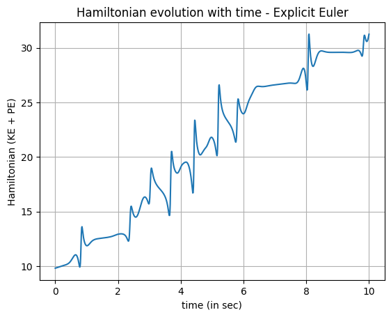

```python
x_traj_euler = simulate(double_pendulum, x0, [t0, tf], dt, euler_integrate)
# print(x_traj.shape)
hamiltonian_traj_euler = compute_hamiltonian_traj(x_traj_euler)

plt.title(r"Hamiltonian evolution with time - Explicit Euler")
plt.xlabel("time (in sec)")
plt.ylabel("Hamiltonian (KE + PE)")
plt.grid(True)
plt.plot(tvec, hamiltonian_traj_euler)
```

### Observation

In the above example, the total eneergy is the Hamiltonian which is a conserved quantity and should remain constant over time.

- In the first plot, where the Hamiltonian is calculated using trajectories from the RK4 solver, the Hamiltonian shows an oscillatory behavior, and the average energy is decreasing with time, indicating that the solver exhibits dissipative behavior.
- In the second plot, where the Hamiltonian is calculated using trajectories from Explicit Euler integration, the Hamiltonian increasing with time, causing the system's average energy to rise, indicating instability in the solver.